# Lab 2: Spatial Analysis and Visualization

Healthcare Access and Equity in Pennsylvania

Author

Daisy Yuan

Published

February 21, 2026

## Assignment Overview

**Learning Objectives:** - Apply spatial operations to answer policy-relevant research questions - Integrate census demographic data with spatial analysis - Create publication-quality visualizations and maps - Work with spatial data from multiple sources - Communicate findings effectively for policy audiences

## Part 1: Healthcare Access for Vulnerable Populations

### Research Question

**Which Pennsylvania counties have the highest proportion of vulnerable populations (elderly + low-income) living far from hospitals?**

Your analysis should identify counties that should be priorities for healthcare investment and policy intervention.

### Required Analysis Steps

Complete the following analysis, documenting each step with code and brief explanations:

#### Step 1: Data Collection (5 points)

Load the required spatial data: - Pennsylvania county boundaries - Pennsylvania hospitals (from lecture data) - Pennsylvania census tracts

**Your Task:**

```r
#| echo: false
#| message: false
#| results: hide

# Load required packages
library(sf)
library(tidyverse)
library(tigris)
library(tidycensus)
library(scales)
library(patchwork)
library(here)

census_api_key(Sys.getenv("CENSUS_API_KEY"))

# Load spatial data
pa_counties <- st_read(here("data/Pennsylvania_County_Boundaries.shp"))
hospitals <- st_read(here("data/hospitals.geojson"))
# Standardize CRS
hospitals <- st_transform(hospitals, st_crs(pa_counties))
```

**Questions to answer:** - How many hospitals are in your dataset? There are 223 hospitals in my dataset.

#### Step 2: Get Demographic Data

Use `tidycensus` to download tract-level demographic data for Pennsylvania.

**Required variables:** - Total population - Median household income - Population 65 years and over (you may need to sum multiple age categories)

**Your Task:**

**Questions to answer:** - What year of ACS data are you using? 2022 5-year ACS data - How many tracts have missing income data? 62 - What is the median income across all PA census tracts? 70188

#### Step 3: Define Vulnerable Populations

Identify census tracts with vulnerable populations based on TWO criteria: 1. Low median household income (choose an appropriate threshold) 2. Significant elderly population (choose an appropriate threshold)

**Your Task:**

**Questions to answer:** - What income threshold did you choose and why? I chose the 25th percentile of median household income across PA tracts — meaning that tracts with income in the bottom quarter of the state are flagged

- What elderly population threshold did you choose and why? I chose the 75th percentile of elderly share across PA tracts — meaning that tracts where the proportion of 65+ residents falls in the top quarter of the state are flagged.
- How many tracts meet your vulnerability criteria? 165 out of 3,383 valid PA census tracts meet the vulnerability criteria.
- What percentage of PA census tracts are considered vulnerable by your definition? Approximately 4.9% of valid PA census tracts are considered vulnerable by this definition.

#### Step 4: Calculate Distance to Hospitals

For each vulnerable tract, calculate the distance to the nearest hospital.

**Your Task:**

```
[1] 4.745881
```

```
[1] 19.15872
```

```
[1] 9
```

**Requirements:** - Use an appropriate projected coordinate system for Pennsylvania - Calculate distances in miles - Explain why you chose your projection

**Questions to answer:** - What is the average distance to the nearest hospital for vulnerable tracts? On average, vulnerable tracts are 4.75 miles from the nearest hospital.

- What is the maximum distance? The maximum distance to the nearest hospital among vulnerable tracts is 19.16 miles.
- How many vulnerable tracts are more than 15 miles from the nearest hospital? NINE vulnerable tracts are more than 15 miles from the nearest hospital.

#### Step 5: Identify Underserved Areas

Define “underserved” as vulnerable tracts that are more than 15 miles from the nearest hospital.

**Your Task:**

```
[1] 9
```

```
[1] 5.454545
```

**Questions to answer:** - How many tracts are underserved? Nine.

- What percentage of vulnerable tracts are underserved? Approximately 5.5% vulnerable tracts are defined as underserved.
- Does this surprise you? Why or why not? This is not entirely surprising. Pennsylvania has a relatively dense hospital network, particularly in urban areas like Philadelphia and Pittsburgh, which keeps most tracts within reasonable distance. At 5.5%, the underserved share is reasonably small — but the 9 tracts that do exceed 15 miles are concerning, as low-income elderly residents in these areas are least likely to have reliable transportation to bridge that gap.

#### Step 6: Aggregate to County Level

Use spatial joins and aggregation to calculate county-level statistics about vulnerable populations and hospital access.

**Your Task:**

```r
# Spatial join tracts to counties
vulnerable_tracts <- st_transform(vulnerable_tracts, st_crs(pa_counties))
vulnerable_with_county <- vulnerable_tracts %>%
  st_join(pa_counties %>% select(COUNTY_NAM))

# Aggregate statistics by county
county_stats <- vulnerable_with_county %>%
  st_drop_geometry() %>%
  group_by(COUNTY_NAM) %>%
  summarise(
    n_vulnerable = n(),
    n_underserved = sum(underserved, na.rm = TRUE),
    pct_underserved = (n_underserved / n_vulnerable) * 100,
    avg_dist = mean(nearest_hosp_dist, na.rm = TRUE),
    total_vulnerable_pop = sum(pop_65_plus, na.rm = TRUE)
  ) %>%
  arrange(desc(n_vulnerable))

# Top 5 counties by percentage underserved
county_stats %>%
  arrange(desc(pct_underserved)) %>%
  head(5)
```

```
# A tibble: 5 × 6
  COUNTY_NAM n_vulnerable n_underserved pct_underserved avg_dist
  <chr>             <int>         <int>           <dbl>    <dbl>
1 PERRY                 2             2             100     17.5
2 BRADFORD              1             1             100     16.7
3 COLUMBIA              1             1             100     16.9
4 JUNIATA               1             1             100     15.9
5 MONROE                1             1             100     17.7
# ℹ 1 more variable: total_vulnerable_pop <dbl>
```

```r
# Counties with most vulnerable people far from hospitals
county_stats %>%
  filter(n_underserved > 0) %>%
  arrange(desc(total_vulnerable_pop)) %>%
  head(5)
```

```
# A tibble: 5 × 6
  COUNTY_NAM     n_vulnerable n_underserved pct_underserved avg_dist
  <chr>                 <int>         <int>           <dbl>    <dbl>
1 LUZERNE                   8             1            12.5     5.03
2 WARREN                    7             1            14.3     6.87
3 CRAWFORD                  6             1            16.7     8.36
4 CLEARFIELD                5             1            20      10.1
5 NORTHUMBERLAND            5             1            20      12.8
# ℹ 1 more variable: total_vulnerable_pop <dbl>
```

**Required county-level statistics:** - Number of vulnerable tracts - Number of underserved tracts  
- Percentage of vulnerable tracts that are underserved - Average distance to nearest hospital for vulnerable tracts - Total vulnerable population

**Questions to answer:** - Which 5 counties have the highest percentage of underserved vulnerable tracts? Perry, Bradford, Columbia, Juniata, and Monroe all have 100% of their vulnerable tracts classified as underserved, with average distances ranging from 15.9 to 17.7 miles from the nearest hospital.

- Which counties have the most vulnerable people living far from hospitals? Luzerne leads with 6,125 vulnerable elderly residents and 1 underserved tract, followed by Warren (5,963), Crawford (4,683), Clearfield (4,368), and Northumberland (3,395).
- Are there any patterns in where underserved counties are located? The underserved counties are predominantly rural, located in central and northern Pennsylvania (Perry, Juniata, Columbia, Bradford, Clearfield, Warren, Crawford). This aligns with the broader pattern of rural healthcare deserts, where low population density makes hospital infrastructure harder to sustain.

#### Step 7: Create Summary Table

Create a professional table showing the top 10 priority counties for healthcare investment.

**Your Task:**

```r
# Create and format priority counties table
library(knitr)
library(kableExtra)

county_stats %>%
  arrange(desc(pct_underserved), desc(total_vulnerable_pop)) %>%
  head(10) %>%
  mutate(
    avg_dist = round(avg_dist, 2),
    pct_underserved = round(pct_underserved, 1),
    total_vulnerable_pop = comma(total_vulnerable_pop)
  ) %>%
  rename(
    "County" = COUNTY_NAM,
    "Vulnerable Tracts" = n_vulnerable,
    "Underserved Tracts" = n_underserved,
    "% Underserved" = pct_underserved,
    "Avg. Distance to Hospital (miles)" = avg_dist,
    "Total Vulnerable Population" = total_vulnerable_pop
  ) %>%
  kable(
    caption = "Top 10 Priority Counties for Healthcare Investment in Pennsylvania: Counties with the highest share of vulnerable tracts lacking adequate hospital access",
    align = c("l", "c", "c", "c", "c", "c")
  ) %>%
  kable_styling(
    bootstrap_options = c("striped", "hover", "condensed"),
    full_width = FALSE
  )
```

Top 10 Priority Counties for Healthcare Investment in Pennsylvania: Counties with the highest share of vulnerable tracts lacking adequate hospital access

| County | Vulnerable Tracts | Underserved Tracts | % Underserved | Avg. Distance to Hospital (miles) | Total Vulnerable Population |
| --- | --- | --- | --- | --- | --- |
| PERRY | 2 | 2 | 100 | 17.53 | 1,558 |
| BRADFORD | 1 | 1 | 100 | 16.66 | 1,545 |
| JUNIATA | 1 | 1 | 100 | 15.91 | 492 |
| MONROE | 1 | 1 | 100 | 17.68 | 314 |
| COLUMBIA | 1 | 1 | 100 | 16.91 | 282 |
| SULLIVAN | 1 | 1 | 100 | 16.91 | 282 |
| DAUPHIN | 2 | 1 | 50 | 9.95 | 2,122 |
| TIOGA | 2 | 1 | 50 | 8.65 | 1,416 |
| CLINTON | 2 | 1 | 50 | 11.03 | 1,402 |
| FOREST | 2 | 1 | 50 | 15.25 | 1,311 |

**Requirements:** - Use `knitr::kable()` or similar for formatting - Include descriptive column names - Format numbers appropriately (commas for population, percentages, etc.) - Add an informative caption - Sort by priority (you decide the metric)

## Part 2: Comprehensive Visualization

Using the skills from Week 3 (Data Visualization), create publication-quality maps and charts.

### Map 1: County-Level Choropleth

Create a choropleth map showing healthcare access challenges at the county level.

**Your Task:**

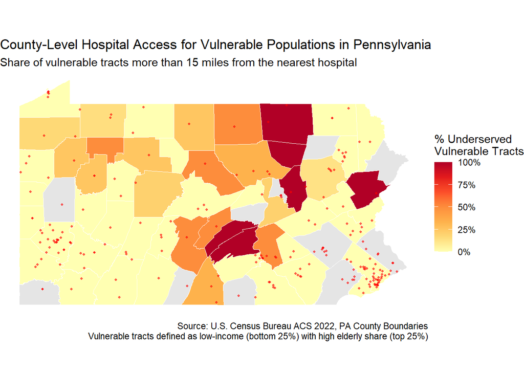

```r
# Create county-level access map
hospitals <- st_transform(hospitals, st_crs(pa_counties))

# Join county_stats to pa_counties spatial data
county_map <- pa_counties %>%
  left_join(county_stats, by = "COUNTY_NAM")

# Create county-level access map
ggplot() +
  geom_sf(data = county_map,
          aes(fill = pct_underserved),
          color = "white", linewidth = 0.3) +
  geom_sf(data = hospitals,
          color = "red", size = 0.8, alpha = 0.6) +
  scale_fill_distiller(
    palette = "YlOrRd",
    direction = 1,
    na.value = "gray90",
    name = "% Underserved\nVulnerable Tracts",
    labels = scales::label_percent(scale = 1)
  ) +
  labs(
    title = "County-Level Hospital Access for Vulnerable Populations in Pennsylvania",
    subtitle = "Share of vulnerable tracts more than 15 miles from the nearest hospital",
    caption = "Source: U.S. Census Bureau ACS 2022, PA County Boundaries\nVulnerable tracts defined as low-income (bottom 25%) with high elderly share (top 25%)"
  ) +
  theme_void()
```

**Requirements:** - Fill counties by percentage of vulnerable tracts that are underserved - Include hospital locations as points - Use an appropriate color scheme - Include clear title, subtitle, and caption - Use `theme_void()` or similar clean theme - Add a legend with formatted labels

### Map 2: Detailed Vulnerability Map

Create a map highlighting underserved vulnerable tracts.

**Your Task:**

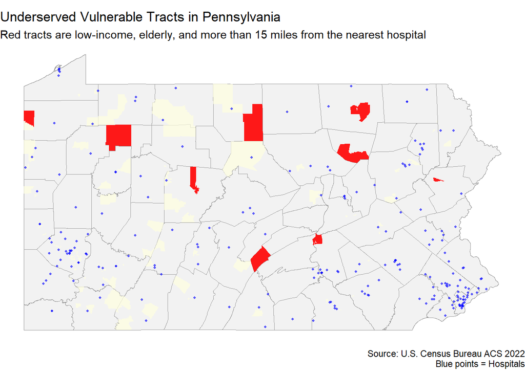

```r
# Create detailed tract-level map
ggplot() +
  geom_sf(data = pa_counties,
          fill = "gray95", color = "gray60", linewidth = 0.3) +
  geom_sf(data = vulnerable_tracts %>% filter(!underserved),
          fill = "lightyellow", color = NA, alpha = 0.7) +
  geom_sf(data = vulnerable_tracts %>% filter(underserved),
          fill = "red", color = NA, alpha = 0.9) +
  geom_sf(data = hospitals,
          color = "blue", size = 0.8, alpha = 0.6) +
  labs(
    title = "Underserved Vulnerable Tracts in Pennsylvania",
    subtitle = "Red tracts are low-income, elderly, and more than 15 miles from the nearest hospital",
    caption = "Source: U.S. Census Bureau ACS 2022\nBlue points = Hospitals"
  ) +
  theme_void()
```

**Requirements:** - Show underserved vulnerable tracts in a contrasting color - Include county boundaries for context - Show hospital locations - Use appropriate visual hierarchy (what should stand out?) - Include informative title and subtitle